# 40 Sales Forecasting Introduction

# 41 Introduction

When we work in Demand and Supply Planning, we often need to create some sales forecasts.

We’re going to present here 2 approaches to create those forecasts :

- **time series forecasts.**
  - a traditional approach, with very often pretty good results; we will go through 3 popular methods :
    - **MLR** (Multi Linear Regression).
    - **Holts-Winter**, also called exponential smoothing.
    - **ARIMA** (Auto Regressive Moving Average).
  - R, and in particular the package `forecast` , proposes some functions to perform those calculations.
- **machine learning forecasts.**
  - a more “modern” approach, using the R package [`xgboost`](https://cran.r-project.org/web/packages/xgboost/index.html).

Both approaches use historical data (*at least 24 months*) and aim to identify a trend and seasonality, and to reproduce it in the future.

At least 24 months of historical data are needed, because we want to make sure to identify a relevant seasonality (if any), so for this we need to compare 2 historical years.

In this section we won’t go into the mathematical details of each algorithm (statistical forecasting is a large topic, and there are several books dedicated to them).

We will instead :

- introduce how to perform those calculations using R.
- measure the accuracy of our model, using a **train | test | validate** approach.
- calculate statistical forecasts for a portfolio of products.
- measure the forecasts performance at a defined lag.
  - for example at lag3, comparing the actual figures vs a forecast done 3 months earlier.
  - with 2 formulas : forecast accuracy and forecast bias.

# 42 Train | Test | Validate

This step is particularly useful **to verify whether our model is relevant** :

- we consider for example 3 years (so 36 months) of historical data.
- we split our dataset into 2 parts (see figure below).
  - **a training part** : using the first 30 months.
  - **a testing part** : the last 6 months.

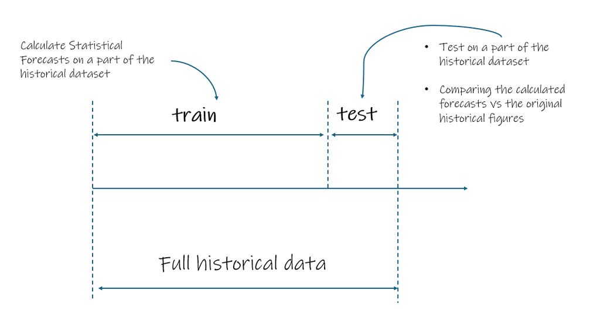

Figure 70 : train | test | validate

- **we calculate some statistical forecasts using the training part.**
- and **we compare the calculated results for the last 6 months for example** (see 2nd figure below).
  - comparing the historical figures vs the calculated forecasts.
    - the closer the 2 figures are, the better.
  - **this approach also helps to identify the best statistical model.**
    - comparing different algorithms.
    - or comparing different calculations for a same model, for example by choosing different training horizons.

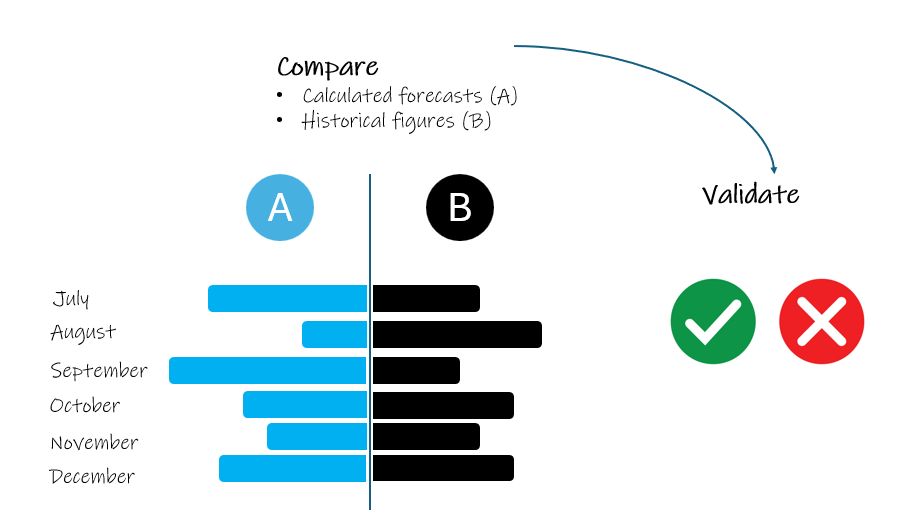

Figure 71 : compare and validate

# 43 Forecasts Performance

There are several ways to calculate the accuracy of forecasts, among them :

- **Mean Absolute Percentage Error** (MAPE).
  - **Calculates the average of the absolute percentage errors between the forecast and the actual values.**
  - it is intuitive because it expresses accuracy as a percentage, making it easy to understand (e.g., a 5% MAPE means the average error is 5% of the actual value).
  - A lower MAPE indicates a more accurate forecast.
  - **Formula:** 𝑀𝐴𝑃𝐸=mean(|Actual−ForecastActual|)×100.
- **Mean Absolute Deviation** (MAD).
  - **Calculates the average of the absolute differences between the forecast and actual values**
  - It provides the average error in the same units as the data (e.g., units of a product).
  - It is best for comparing a single product’s accuracy, as using it for items with very different demand volumes can skew the results.
  - A smaller MAD indicates a more accurate forecast.
  - **Formula:** 𝑀𝐴𝐷=mean(|Actual−Forecast|).
- **Mean Square Error** (MSE).
  - **Calculates the average of the squared errors between the forecast and actual values**
  - Squaring the errors penalizes larger errors more heavily than smaller ones.
  - A smaller MSE indicates a better forecast.
  - **Formula:** 𝑀𝑆𝐸=mean((Actual−Forecast)2).

Now, let’s practice and start calculating some statistical forecasts!